# Risk Factor Analysis

## Outcome Variable

**Outcome Variable:** ever_wasted

## Predictor Variables

**Intervention Variable:** perdiar24

**Adjustment Set:**

- arm
- sex
- W_mage
- meducyrs
- feducyrs
- hhwealth_quart
- hfoodsec
- hdlvry
- W_birthwt
- W_birthlen
- single
- W_nrooms
- month
- brthmon
- impfloor
- impsan
- safeh20
- delta_W_mage
- delta_meducyrs
- delta_feducyrs
- delta_hhwealth_quart
- delta_hfoodsec
- delta_hdlvry
- delta_W_birthwt
- delta_W_birthlen
- delta_single
- delta_W_nrooms
- delta_month
- delta_brthmon
- delta_impfloor
- delta_impsan
- delta_safeh20

## Stratifying Variables

The analysis was stratified on these variable(s):

- agecat
- studyid
- country

## Data Summary

| agecat | studyid | country | perdiar24 | ever_wasted | n_cell | n |
| --- | --- | --- | --- | --- | --- | --- |
| 0-24 months (no birth wast) | CMIN | BANGLADESH | 0% | 0 | 8 | 268 |
| 0-24 months (no birth wast) | CMIN | BANGLADESH | 0% | 1 | 1 | 268 |
| 0-24 months (no birth wast) | CMIN | BANGLADESH | (0%, 5%] | 0 | 69 | 268 |
| 0-24 months (no birth wast) | CMIN | BANGLADESH | (0%, 5%] | 1 | 51 | 268 |
| 0-24 months (no birth wast) | CMIN | BANGLADESH | >5% | 0 | 76 | 268 |
| 0-24 months (no birth wast) | CMIN | BANGLADESH | >5% | 1 | 63 | 268 |
| 0-24 months (no birth wast) | CONTENT | PERU | 0% | 0 | 6 | 215 |
| 0-24 months (no birth wast) | CONTENT | PERU | 0% | 1 | 0 | 215 |
| 0-24 months (no birth wast) | CONTENT | PERU | (0%, 5%] | 0 | 139 | 215 |
| 0-24 months (no birth wast) | CONTENT | PERU | (0%, 5%] | 1 | 3 | 215 |
| 0-24 months (no birth wast) | CONTENT | PERU | >5% | 0 | 66 | 215 |
| 0-24 months (no birth wast) | CONTENT | PERU | >5% | 1 | 1 | 215 |
| 0-24 months (no birth wast) | EE | PAKISTAN | 0% | 0 | 123 | 377 |
| 0-24 months (no birth wast) | EE | PAKISTAN | 0% | 1 | 137 | 377 |
| 0-24 months (no birth wast) | EE | PAKISTAN | (0%, 5%] | 0 | 51 | 377 |
| 0-24 months (no birth wast) | EE | PAKISTAN | (0%, 5%] | 1 | 66 | 377 |
| 0-24 months (no birth wast) | EE | PAKISTAN | >5% | 0 | 0 | 377 |
| 0-24 months (no birth wast) | EE | PAKISTAN | >5% | 1 | 0 | 377 |
| 0-24 months (no birth wast) | Guatemala BSC | GUATEMALA | 0% | 0 | 30 | 307 |
| 0-24 months (no birth wast) | Guatemala BSC | GUATEMALA | 0% | 1 | 2 | 307 |
| 0-24 months (no birth wast) | Guatemala BSC | GUATEMALA | (0%, 5%] | 0 | 63 | 307 |
| 0-24 months (no birth wast) | Guatemala BSC | GUATEMALA | (0%, 5%] | 1 | 8 | 307 |
| 0-24 months (no birth wast) | Guatemala BSC | GUATEMALA | >5% | 0 | 188 | 307 |
| 0-24 months (no birth wast) | Guatemala BSC | GUATEMALA | >5% | 1 | 16 | 307 |
| 0-24 months (no birth wast) | iLiNS-Zinc | BURKINA FASO | 0% | 0 | 307 | 2348 |
| 0-24 months (no birth wast) | iLiNS-Zinc | BURKINA FASO | 0% | 1 | 22 | 2348 |
| 0-24 months (no birth wast) | iLiNS-Zinc | BURKINA FASO | (0%, 5%] | 0 | 1169 | 2348 |
| 0-24 months (no birth wast) | iLiNS-Zinc | BURKINA FASO | (0%, 5%] | 1 | 114 | 2348 |
| 0-24 months (no birth wast) | iLiNS-Zinc | BURKINA FASO | >5% | 0 | 651 | 2348 |
| 0-24 months (no birth wast) | iLiNS-Zinc | BURKINA FASO | >5% | 1 | 85 | 2348 |

[output cut: 168 more lines]

The following strata were considered:

- agecat: 0-24 months (no birth wast), studyid: CMIN, country: BANGLADESH
- agecat: 0-24 months (no birth wast), studyid: CONTENT, country: PERU
- agecat: 0-24 months (no birth wast), studyid: EE, country: PAKISTAN
- agecat: 0-24 months (no birth wast), studyid: Guatemala BSC, country: GUATEMALA
- agecat: 0-24 months (no birth wast), studyid: iLiNS-Zinc, country: BURKINA FASO
- agecat: 0-24 months (no birth wast), studyid: JiVitA-4, country: BANGLADESH
- agecat: 0-24 months (no birth wast), studyid: MAL-ED, country: BANGLADESH
- agecat: 0-24 months (no birth wast), studyid: MAL-ED, country: BRAZIL
- agecat: 0-24 months (no birth wast), studyid: MAL-ED, country: INDIA
- agecat: 0-24 months (no birth wast), studyid: MAL-ED, country: NEPAL
- agecat: 0-24 months (no birth wast), studyid: MAL-ED, country: PERU
- agecat: 0-24 months (no birth wast), studyid: MAL-ED, country: SOUTH AFRICA
- agecat: 0-24 months (no birth wast), studyid: MAL-ED, country: TANZANIA, UNITED REPUBLIC OF
- agecat: 0-24 months (no birth wast), studyid: NIH-Birth, country: BANGLADESH
- agecat: 0-24 months (no birth wast), studyid: NIH-Crypto, country: BANGLADESH
- agecat: 0-24 months (no birth wast), studyid: PROVIDE, country: BANGLADESH
- agecat: 0-24 months (no birth wast), studyid: SAS-FoodSuppl, country: INDIA
- agecat: 0-6 months (no birth wast), studyid: CMIN, country: BANGLADESH
- agecat: 0-6 months (no birth wast), studyid: CONTENT, country: PERU
- agecat: 0-6 months (no birth wast), studyid: EE, country: PAKISTAN
- agecat: 0-6 months (no birth wast), studyid: Guatemala BSC, country: GUATEMALA
- agecat: 0-6 months (no birth wast), studyid: JiVitA-4, country: BANGLADESH
- agecat: 0-6 months (no birth wast), studyid: MAL-ED, country: BANGLADESH
- agecat: 0-6 months (no birth wast), studyid: MAL-ED, country: BRAZIL
- agecat: 0-6 months (no birth wast), studyid: MAL-ED, country: INDIA
- agecat: 0-6 months (no birth wast), studyid: MAL-ED, country: NEPAL
- agecat: 0-6 months (no birth wast), studyid: MAL-ED, country: PERU
- agecat: 0-6 months (no birth wast), studyid: MAL-ED, country: SOUTH AFRICA
- agecat: 0-6 months (no birth wast), studyid: MAL-ED, country: TANZANIA, UNITED REPUBLIC OF
- agecat: 0-6 months (no birth wast), studyid: NIH-Birth, country: BANGLADESH
- agecat: 0-6 months (no birth wast), studyid: NIH-Crypto, country: BANGLADESH
- agecat: 0-6 months (no birth wast), studyid: PROVIDE, country: BANGLADESH
- agecat: 0-6 months (no birth wast), studyid: SAS-FoodSuppl, country: INDIA

### Dropped Strata

Some strata were dropped due to rare outcomes:

- agecat: 0-24 months (no birth wast), studyid: CMIN, country: BANGLADESH
- agecat: 0-24 months (no birth wast), studyid: CONTENT, country: PERU
- agecat: 0-24 months (no birth wast), studyid: EE, country: PAKISTAN
- agecat: 0-24 months (no birth wast), studyid: Guatemala BSC, country: GUATEMALA
- agecat: 0-24 months (no birth wast), studyid: MAL-ED, country: BANGLADESH
- agecat: 0-24 months (no birth wast), studyid: MAL-ED, country: BRAZIL
- agecat: 0-24 months (no birth wast), studyid: MAL-ED, country: INDIA
- agecat: 0-24 months (no birth wast), studyid: MAL-ED, country: NEPAL
- agecat: 0-24 months (no birth wast), studyid: MAL-ED, country: PERU
- agecat: 0-24 months (no birth wast), studyid: MAL-ED, country: SOUTH AFRICA
- agecat: 0-24 months (no birth wast), studyid: MAL-ED, country: TANZANIA, UNITED REPUBLIC OF
- agecat: 0-24 months (no birth wast), studyid: NIH-Birth, country: BANGLADESH
- agecat: 0-24 months (no birth wast), studyid: PROVIDE, country: BANGLADESH
- agecat: 0-6 months (no birth wast), studyid: CMIN, country: BANGLADESH
- agecat: 0-6 months (no birth wast), studyid: CONTENT, country: PERU
- agecat: 0-6 months (no birth wast), studyid: EE, country: PAKISTAN
- agecat: 0-6 months (no birth wast), studyid: Guatemala BSC, country: GUATEMALA
- agecat: 0-6 months (no birth wast), studyid: JiVitA-4, country: BANGLADESH
- agecat: 0-6 months (no birth wast), studyid: MAL-ED, country: BANGLADESH
- agecat: 0-6 months (no birth wast), studyid: MAL-ED, country: BRAZIL
- agecat: 0-6 months (no birth wast), studyid: MAL-ED, country: INDIA
- agecat: 0-6 months (no birth wast), studyid: MAL-ED, country: NEPAL
- agecat: 0-6 months (no birth wast), studyid: MAL-ED, country: PERU
- agecat: 0-6 months (no birth wast), studyid: MAL-ED, country: SOUTH AFRICA
- agecat: 0-6 months (no birth wast), studyid: MAL-ED, country: TANZANIA, UNITED REPUBLIC OF
- agecat: 0-6 months (no birth wast), studyid: NIH-Birth, country: BANGLADESH
- agecat: 0-6 months (no birth wast), studyid: NIH-Crypto, country: BANGLADESH
- agecat: 0-6 months (no birth wast), studyid: PROVIDE, country: BANGLADESH
- agecat: 0-6 months (no birth wast), studyid: SAS-FoodSuppl, country: INDIA

## Methods Detail

We're interested in the causal parameters $E[Y_a]$ for all values of $a \in \mathcal{A}$. These parameters represent the mean outcome if, possibly contrary to fact, we intervened to set all units to have $A=a$. Under the randomization and positivity assumptions, these are identified by the statistical parameters $\psi_a=E_W[E_{Y|A,W}(Y|A=a,W)]$. In addition, we're interested in the mean of $Y$, $E[Y]$ under no intervention (the observed mean). We will estimate these parameters by using SuperLearner to fit the relevant likelihood factors -- $E_{Y|A,W}(Y|A=a,W)$ and $p(A=a|W)$, and then updating our likelihood fit using a joint TMLE.

For unadjusted analyses ($W=\{\}$), initial likelihoods were estimated using Lrnr_glm to estimate the simple $E(Y|A)$ and Lrnr_mean to estimate $p(A)$. For adjusted analyses, a small library containing Lrnr_glmnet, Lrnr_xgboost, and Lrnr_mean was used.

Having estimated these parameters, we will then use the delta method to estimate relative risks and attributable risks relative to a prespecified baseline level of $A$.

# Results Detail

## Results Plots

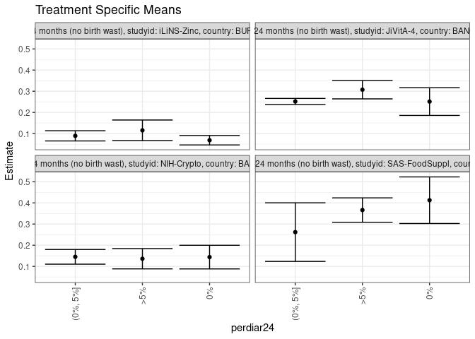

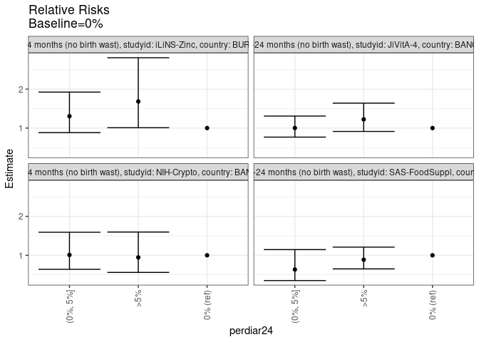

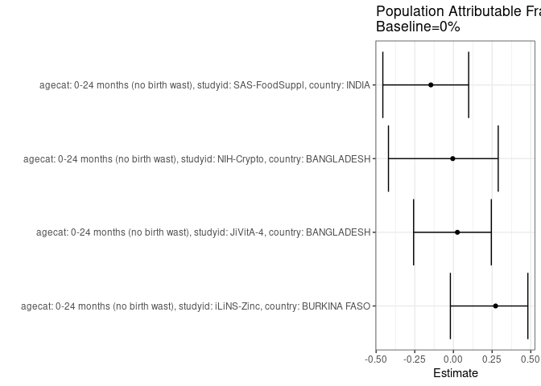

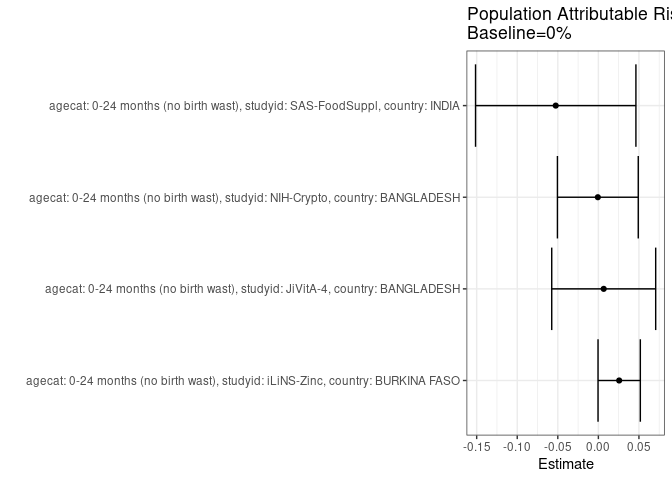

## Results Table

### Parameter: TSM

| agecat | studyid | country | intervention_level | baseline_level | estimate | ci_lower | ci_upper |
| --- | --- | --- | --- | --- | --- | --- | --- |
| 0-24 months (no birth wast) | iLiNS-Zinc | BURKINA FASO | 0% | NA | 0.0684658 | 0.0460807 | 0.0908509 |
| 0-24 months (no birth wast) | iLiNS-Zinc | BURKINA FASO | (0%, 5%] | NA | 0.0892313 | 0.0651105 | 0.1133522 |
| 0-24 months (no birth wast) | iLiNS-Zinc | BURKINA FASO | >5% | NA | 0.1152295 | 0.0664673 | 0.1639917 |
| 0-24 months (no birth wast) | JiVitA-4 | BANGLADESH | 0% | NA | 0.2511997 | 0.1856363 | 0.3167632 |
| 0-24 months (no birth wast) | JiVitA-4 | BANGLADESH | (0%, 5%] | NA | 0.2516592 | 0.2373031 | 0.2660153 |
| 0-24 months (no birth wast) | JiVitA-4 | BANGLADESH | >5% | NA | 0.3073734 | 0.2639052 | 0.3508415 |
| 0-24 months (no birth wast) | NIH-Crypto | BANGLADESH | 0% | NA | 0.1438790 | 0.0880706 | 0.1996874 |
| 0-24 months (no birth wast) | NIH-Crypto | BANGLADESH | (0%, 5%] | NA | 0.1452633 | 0.1105224 | 0.1800043 |
| 0-24 months (no birth wast) | NIH-Crypto | BANGLADESH | >5% | NA | 0.1361327 | 0.0882065 | 0.1840589 |
| 0-24 months (no birth wast) | SAS-FoodSuppl | INDIA | 0% | NA | 0.4127615 | 0.3026687 | 0.5228544 |
| 0-24 months (no birth wast) | SAS-FoodSuppl | INDIA | (0%, 5%] | NA | 0.2619716 | 0.1234818 | 0.4004613 |
| 0-24 months (no birth wast) | SAS-FoodSuppl | INDIA | >5% | NA | 0.3662611 | 0.3085672 | 0.4239550 |

### Parameter: E(Y)

| agecat | studyid | country | intervention_level | baseline_level | estimate | ci_lower | ci_upper |
| --- | --- | --- | --- | --- | --- | --- | --- |
| 0-24 months (no birth wast) | iLiNS-Zinc | BURKINA FASO | NA | NA | 0.0941227 | 0.0721577 | 0.1160876 |
| 0-24 months (no birth wast) | JiVitA-4 | BANGLADESH | NA | NA | 0.2577835 | 0.2441424 | 0.2714247 |
| 0-24 months (no birth wast) | NIH-Crypto | BANGLADESH | NA | NA | 0.1432361 | 0.1182149 | 0.1682572 |
| 0-24 months (no birth wast) | SAS-FoodSuppl | INDIA | NA | NA | 0.3602015 | 0.3129196 | 0.4074834 |

### Parameter: RR

| agecat | studyid | country | intervention_level | baseline_level | estimate | ci_lower | ci_upper |
| --- | --- | --- | --- | --- | --- | --- | --- |
| 0-24 months (no birth wast) | iLiNS-Zinc | BURKINA FASO | 0% | 0% | 1.0000000 | 1.0000000 | 1.000000 |
| 0-24 months (no birth wast) | iLiNS-Zinc | BURKINA FASO | (0%, 5%] | 0% | 1.3032975 | 0.8829066 | 1.923855 |
| 0-24 months (no birth wast) | iLiNS-Zinc | BURKINA FASO | >5% | 0% | 1.6830224 | 1.0093410 | 2.806350 |
| 0-24 months (no birth wast) | JiVitA-4 | BANGLADESH | 0% | 0% | 1.0000000 | 1.0000000 | 1.000000 |
| 0-24 months (no birth wast) | JiVitA-4 | BANGLADESH | (0%, 5%] | 0% | 1.0018292 | 0.7674984 | 1.307705 |
| 0-24 months (no birth wast) | JiVitA-4 | BANGLADESH | >5% | 0% | 1.2236213 | 0.9126319 | 1.640584 |
| 0-24 months (no birth wast) | NIH-Crypto | BANGLADESH | 0% | 0% | 1.0000000 | 1.0000000 | 1.000000 |
| 0-24 months (no birth wast) | NIH-Crypto | BANGLADESH | (0%, 5%] | 0% | 1.0096213 | 0.6402079 | 1.592194 |
| 0-24 months (no birth wast) | NIH-Crypto | BANGLADESH | >5% | 0% | 0.9461609 | 0.5604612 | 1.597292 |
| 0-24 months (no birth wast) | SAS-FoodSuppl | INDIA | 0% | 0% | 1.0000000 | 1.0000000 | 1.000000 |
| 0-24 months (no birth wast) | SAS-FoodSuppl | INDIA | (0%, 5%] | 0% | 0.6346802 | 0.3514462 | 1.146175 |
| 0-24 months (no birth wast) | SAS-FoodSuppl | INDIA | >5% | 0% | 0.8873433 | 0.6508499 | 1.209769 |

### Parameter: PAR

| agecat | studyid | country | intervention_level | baseline_level | estimate | ci_lower | ci_upper |
| --- | --- | --- | --- | --- | --- | --- | --- |
| 0-24 months (no birth wast) | iLiNS-Zinc | BURKINA FASO | 0% | NA | 0.0256569 | -0.0004100 | 0.0517237 |
| 0-24 months (no birth wast) | JiVitA-4 | BANGLADESH | 0% | NA | 0.0065838 | -0.0574877 | 0.0706553 |
| 0-24 months (no birth wast) | NIH-Crypto | BANGLADESH | 0% | NA | -0.0006430 | -0.0504647 | 0.0491787 |
| 0-24 months (no birth wast) | SAS-FoodSuppl | INDIA | 0% | NA | -0.0525600 | -0.1513958 | 0.0462758 |

### Parameter: PAF

| agecat | studyid | country | intervention_level | baseline_level | estimate | ci_lower | ci_upper |
| --- | --- | --- | --- | --- | --- | --- | --- |
| 0-24 months (no birth wast) | iLiNS-Zinc | BURKINA FASO | 0% | NA | 0.2725895 | -0.0198238 | 0.4811594 |
| 0-24 months (no birth wast) | JiVitA-4 | BANGLADESH | 0% | NA | 0.0255400 | -0.2575931 | 0.2449288 |
| 0-24 months (no birth wast) | NIH-Crypto | BANGLADESH | 0% | NA | -0.0044888 | -0.4201359 | 0.2895062 |
| 0-24 months (no birth wast) | SAS-FoodSuppl | INDIA | 0% | NA | -0.1459183 | -0.4564930 | 0.0984311 |